# Women's Clothing E-Commerce Reviews

# Purspose and Objectives

## Purpose

The purpose of this project is to harness the power of data science to scrutinize customer reviews on women's clothing from an e-commerce platform. By doing so, it aims to extract actionable insights that can enhance customer satisfaction and boost sales. The project will delve into various facets of the reviews, such as:

1. Identifying Trends: Recognizing patterns in customer satisfaction based on ratings and recommendations. This will provide an overarching view of how customers feel about different products.
2. Pattern Discovery: Unearthing common themes in positive and negative feedback. This will help in understanding what aspects of the products are appreciated or criticized the most.
3. Demographic Insights: Exploring the relationship between customer demographics (like age) and product ratings. This will offer insights into which demographic segments are more satisfied with which products.

## Scope

The scope of the analysis includes:

The project involves analyzing customer reviews for women's clothing on an e-commerce platform. The scope includes data collection and cleaning, exploratory data analysis to identify patterns and sentiment analysis using natural language processing (NLP) techniques. The analysis aims to uncover trends in customer satisfaction, understand the relationship between demographics and ratings, and identify common themes in feedback. The findings will be used to provide actionable recommendations for product improvement and customer engagement, ultimately enhancing customer satisfaction and driving sales.

# Objectives

1.Analyze Customer Satisfaction Trends:

To identify trends in customer satisfaction based on ratings and recommendations, allowing for an overarching view of how customers feel about different products.

2.Discover Patterns in Feedback:

To unearth common themes in positive and negative feedback, providing insights into what aspects of the products are appreciated or criticized the most.

3.Correlate Demographics and Ratings:

To explore the relationship between customer demographics (such as age) and product ratings, offering insights into which demographic segments are more satisfied with which products.

4.Extract Actionable Insights:

To derive actionable insights from the analysis that can be utilized to improve product offerings, enhance customer satisfaction, and drive sales.

5.Generate Reports and Visualizations:

To create detailed reports and visualizations that clearly communicate the findings and insights from the data analysis to stakeholders.

# Problem Aim to Solve

The problem this project aims to solve is the challenge of understanding and enhancing customer satisfaction in the women's clothing segment of an e-commerce platform. Specifically, the project seeks to address the following issues:

- Lack of Insight into Customer Satisfaction: E-commerce platforms often receive a large volume of customer reviews, but extracting meaningful insights from this unstructured data can be challenging. The project aims to analyze these reviews to identify trends and patterns in customer satisfaction.
- Understanding Feedback Patterns: Customers provide feedback in various forms, such as ratings, recommendations, and review texts. This project aims to discover common themes in positive and negative feedback to understand what aspects of the products are appreciated or criticized the most.
- Demographic Analysis: Different demographic groups may have varying preferences and levels of satisfaction. The project aims to explore the relationship between customer demographics (such as age) and product ratings to understand which demographic segments are more satisfied with which products.

# Importance and Relevance of this Project

The importance and relevance of this Women's Clothing E-Commerce Reviews Project can be summarized as follows:

## Importance

Customer Satisfaction Enhancement: By analyzing reviews, the project helps identify key factors that contribute to customer satisfaction and dissatisfaction, leading to improved customer experiences.

Data-Driven Decision Making: Provides valuable insights that can guide business decisions, such as product development, marketing strategies, and inventory management.

Competitive Advantage: Understanding customer preferences and feedback enables the company to stay ahead of competitors by offering products that better meet customer needs.

## Relevance

E-commerce Growth: With the increasing prevalence of online shopping, understanding customer feedback in e-commerce is more critical than ever to ensure sustained growth and success.

Personalization: Insights from the analysis can be used to personalize marketing and product recommendations, leading to higher customer engagement and loyalty.

Diverse Customer Base: The project acknowledges the diversity of customers in terms of demographics, helping tailor products and services to different customer segments.

# Summary

The approach to achieving the objectives of the Women's Clothing E-Commerce Reviews Project involves:

1. Data Collection and Integration: Collecting and integrating customer reviews, ratings, and recommendations from the e-commerce platform.
2. Data Processing and Storage: Cleaning, preprocessing, and storing the review data in a secure database.
3. Data Interpretation and Visualization: Developing algorithms to interpret the reviews and creating user-friendly visualizations to identify key insights.
4. Customer Satisfaction Trends: Analyzing trends in customer satisfaction based on ratings and recommendations.
5. Feedback Pattern Discovery: Identifying patterns in positive and negative feedback to understand customer preferences and concerns.
6. Demographic Analysis: Examining the relationship between customer demographics (such as age) and product ratings to provide targeted insights.
7. Actionable Insights: Extracting actionable insights to improve customer satisfaction and drive sales by addressing identified issues and capitalizing on positive trends.
8. Continuous Improvement: Continuously updating and refining the analysis to ensure ongoing relevance and accuracy.
9. Privacy and Security: Ensuring the privacy and security of customer data through robust encryption and compliance with privacy regulations.

This approach aims to provide valuable insights to enhance the customer experience and boost sales performance in the e-commerce platform.

## Import Libraries

```python
import pandas as pd
import matplotlib.pyplot as plt
import seaborn as sns
from sklearn.feature_extraction.text import CountVectorizer
import nltk
from nltk.corpus import stopwords
from nltk.tokenize import word_tokenize
from textblob import TextBlob
from sklearn.preprocessing import StandardScaler
from sklearn.model_selection import train_test_split , GridSearchCV
from sklearn.tree import DecisionTreeClassifier
from sklearn.metrics import accuracy_score, precision_score, recall_score, f1_score, classification_report
from imblearn.over_sampling import SMOTE
from sklearn.model_selection import GridSearchCV
```

Code Explanation: These libraries are essential for handling data (Pandas, NumPy), creating visualizations (Matplotlib, Seaborn), and building and evaluating machine learning models (Scikit-learn).

Explanation: These libraries are essential for handling data (Pandas, NumPy), creating visualizations (Matplotlib, Seaborn), and building and evaluating machine learning models (Scikit-learn)

## Load Dataset

```python
df = pd.read_csv('Womens Clothing E-Commerce Reviews.csv')
df.head()
```

|  | Unnamed: 0 | Clothing ID | Age | Title | Review Text | Rating | Recommended IND | Positive Feedback Count | Division Name | Department Name | Class Name |
| --- | --- | --- | --- | --- | --- | --- | --- | --- | --- | --- | --- |
| 0 | 0 | 767 | 33 | NaN | Absolutely wonderful - silky and sexy and comf... | 4 | 1 | 0 | Initmates | Intimate | Intimates |
| 1 | 1 | 1080 | 34 | NaN | Love this dress! it's sooo pretty. i happene... | 5 | 1 | 4 | General | Dresses | Dresses |
| 2 | 2 | 1077 | 60 | Some major design flaws | I had such high hopes for this dress and reall... | 3 | 0 | 0 | General | Dresses | Dresses |
| 3 | 3 | 1049 | 50 | My favorite buy! | I love, love, love this jumpsuit. it's fun, fl... | 5 | 1 | 0 | General Petite | Bottoms | Pants |
| 4 | 4 | 847 | 47 | Flattering shirt | This shirt is very flattering to all due to th... | 5 | 1 | 6 | General | Tops | Blouses |

Code Explanation:The dataset is loaded into a DataFrame, and the first few rows are displayed understand the structure and content of the data.

Explanation: Loading the data allows us to inspect the first few rows and understand its structure and contents

## 1. Understand the Dataset

### Explore the dataset to identify column types and understand data distributions.

```python
print(df.info())
print(df.describe())
df.head()
```

```
<class 'pandas.core.frame.DataFrame'>
RangeIndex: 23486 entries, 0 to 23485
Data columns (total 11 columns):
 #   Column                   Non-Null Count  Dtype
---  ------                   --------------  -----
 0   Unnamed: 0               23486 non-null  int64
 1   Clothing ID              23486 non-null  int64
 2   Age                      23486 non-null  int64
 3   Title                    19676 non-null  object
 4   Review Text              22641 non-null  object
 5   Rating                   23486 non-null  int64
 6   Recommended IND          23486 non-null  int64
 7   Positive Feedback Count  23486 non-null  int64
 8   Division Name            23472 non-null  object
 9   Department Name          23472 non-null  object
 10  Class Name               23472 non-null  object
dtypes: int64(6), object(5)
memory usage: 2.0+ MB
None
         Unnamed: 0   Clothing ID           Age        Rating  \
count  23486.000000  23486.000000  23486.000000  23486.000000
mean   11742.500000    918.118709     43.198544      4.196032
std     6779.968547    203.298980     12.279544      1.110031
min        0.000000      0.000000     18.000000      1.000000
25%     5871.250000    861.000000     34.000000      4.000000
50%    11742.500000    936.000000     41.000000      5.000000
75%    17613.750000   1078.000000     52.000000      5.000000
max    23485.000000   1205.000000     99.000000      5.000000

       Recommended IND  Positive Feedback Count
count     23486.000000             23486.000000
mean          0.822362                 2.535936
std           0.382216                 5.702202
min           0.000000                 0.000000
25%           1.000000                 0.000000
50%           1.000000                 1.000000
75%           1.000000                 3.000000
max           1.000000               122.000000
```

|  | Unnamed: 0 | Clothing ID | Age | Title | Review Text | Rating | Recommended IND | Positive Feedback Count | Division Name | Department Name | Class Name |
| --- | --- | --- | --- | --- | --- | --- | --- | --- | --- | --- | --- |
| 0 | 0 | 767 | 33 | NaN | Absolutely wonderful - silky and sexy and comf... | 4 | 1 | 0 | Initmates | Intimate | Intimates |
| 1 | 1 | 1080 | 34 | NaN | Love this dress! it's sooo pretty. i happene... | 5 | 1 | 4 | General | Dresses | Dresses |
| 2 | 2 | 1077 | 60 | Some major design flaws | I had such high hopes for this dress and reall... | 3 | 0 | 0 | General | Dresses | Dresses |
| 3 | 3 | 1049 | 50 | My favorite buy! | I love, love, love this jumpsuit. it's fun, fl... | 5 | 1 | 0 | General Petite | Bottoms | Pants |
| 4 | 4 | 847 | 47 | Flattering shirt | This shirt is very flattering to all due to th... | 5 | 1 | 6 | General | Tops | Blouses |

Code Explanation: These commands explore the dataset by providing a summary of non-null values and data types, generating descriptive statistics for numerical columns, and displaying the first few rows for verification. Together, they help understand the dataset before analysis.

Why it's Important: Using print(df.info()), print(df.describe()), and df.head() helps to understand your dataset's structure, identify missing values, summarize statistics, and verify data correctness, laying the groundwork for effective analysis.

### Note any missing values, outliers, or inconsistencies.

```python
print("Missing Values:")
print(df.isnull().sum())
```

```
Missing Values:
Unnamed: 0                    0
Clothing ID                   0
Age                           0
Title                      3810
Review Text                 845
Rating                        0
Recommended IND               0
Positive Feedback Count       0
Division Name                14
Department Name              14
Class Name                   14
dtype: int64
```

Code Explanation: These commands check for missing values in the dataset. The first command indicates that missing values will be displayed, while the second calculates and shows the total missing values for each column. This is crucial for identifying data gaps before analysis.

Why it's Important: Using commands like print(df.info()), print(df.describe()), and df.head() is essential for initially understanding your dataset's structure, identifying missing values, summarizing key statistics, and verifying that the data is loaded correctly. These steps ensure a solid foundation for effective data cleaning, preprocessing, and analysis.

## 2. Data Cleaning

### Handle missing data using appropriate imputation techniques or by removing incomplete rows if necessary.

```python
numeric_cols = df.select_dtypes(include=['int64', 'float64']).columns
df[numeric_cols] = df[numeric_cols].fillna(df[numeric_cols].mean())

print("Missing Values After Imputation:")
print(df.isnull().sum())
```

```
Missing Values After Imputation:
Unnamed: 0                    0
Clothing ID                   0
Age                           0
Title                      3810
Review Text                 845
Rating                        0
Recommended IND               0
Positive Feedback Count       0
Division Name                14
Department Name              14
Class Name                   14
dtype: int64
```

```python
df['Title'] = df['Title'].fillna(df['Title'].mode()[0])
df['Review Text'] = df['Review Text'].fillna(df['Review Text'].mode()[0])
df['Division Name'] = df['Division Name'].fillna(df['Division Name'].mode()[0])
df['Department Name'] = df['Department Name'].fillna(df['Department Name'].mode()[0])
df['Class Name'] = df['Class Name'].fillna(df['Class Name'].mode()[0])
```

Code Explanation: This code fills missing values in the 'Title,' 'Review Text,' 'Division Name,' 'Department Name,' and 'Class Name' columns with their most frequent values (mode). This ensures completeness and accuracy for analysis.

Why it's Important: This code is crucial because it fills missing values in categorical columns with the mode, ensuring a complete and consistent dataset for accurate analysis and modeling.

```python
print("Missing Values After Imputation:")
print(df.isnull().sum())
```

```
Missing Values After Imputation:
Unnamed: 0                 0
Clothing ID                0
Age                        0
Title                      0
Review Text                0
Rating                     0
Recommended IND            0
Positive Feedback Count    0
Division Name              0
Department Name            0
Class Name                 0
dtype: int64
```

Code Explanation: These commands check for any remaining missing values after imputation. The first command prints a message indicating that the output will show missing values after imputation. The second command calculates and displays the number of missing values for each column, ensuring data completeness before further analysis.

Why it's Important: This code is important because it verifies that the imputation process has successfully filled all missing values in the DataFrame. By printing the count of missing values after imputation, you ensure the dataset is complete and ready for further analysis or modeling, thus maintaining data integrity.

### Standardize column formats where applicable (e.g., age as integers, categorical labels).

```python
df['Age'] = df['Age'].astype(int)

categorical_cols = df.select_dtypes(include=['object']).columns
for col in categorical_cols:
    df[col] = df[col].str.capitalize()

print("Standardized Column Formats:")
print(df.head(10))
```

```
Standardized Column Formats:
   Unnamed: 0  Clothing ID  Age                                 Title  \
0           0          767   33                              Love it!
1           1         1080   34                              Love it!
2           2         1077   60               Some major design flaws
3           3         1049   50                      My favorite buy!
4           4          847   47                      Flattering shirt
5           5         1080   49               Not for the very petite
6           6          858   39                  Cagrcoal shimmer fun
7           7          858   39  Shimmer, surprisingly goes with lots
8           8         1077   24                            Flattering
9           9         1077   34                     Such a fun dress!

                                         Review Text  Rating  Recommended IND  \
0  Absolutely wonderful - silky and sexy and comf...       4                1
```

[output cut: 21 more lines]

Code Explanation: This code standardizes data formats by converting the 'Age' column to an integer and capitalizing the first letter of entries in all categorical columns. Finally, it prints the first ten rows to verify the changes. This ensures consistency for accurate analysis.

Why it's Important: This code ensures data consistency by converting the Age column to integers and capitalizing categorical column values. This standardization improves data quality, making it more reliable for analysis and modeling. Printing the standardized columns allows for verification of the changes.

```python
print("Standardized Column Formats (Selected Columns):")
print(df[['Age', 'Division Name', 'Department Name', 'Class Name','Recommended IND',]].head(10))
```

```
Standardized Column Formats (Selected Columns):
   Age   Division Name Department Name Class Name  Recommended IND
0   33       Initmates        Intimate  Intimates                1
1   34         General         Dresses    Dresses                1
2   60         General         Dresses    Dresses                0
3   50  General petite         Bottoms      Pants                1
4   47         General            Tops    Blouses                1
5   49         General         Dresses    Dresses                0
6   39  General petite            Tops      Knits                1
7   39  General petite            Tops      Knits                1
8   24         General         Dresses    Dresses                1
9   34         General         Dresses    Dresses                1
```

Code Explanation: This code prints a message indicating that selected columns have been standardized and displays the first ten rows of the specified columns to verify the changes. This ensures data consistency.

Why it's Important: This code verifies that the Age column and key categorical columns have been correctly standardized, ensuring data consistency and reliability for analysis and modeling.

## 3. Exploratory Data Analysis (EDA)

### Perform descriptive statistics for all numeric columns.

```python
print("Descriptive Statistics for Numeric Columns:")
print(df.describe())
```

```
Descriptive Statistics for Numeric Columns:
         Unnamed: 0   Clothing ID           Age        Rating  \
count  23486.000000  23486.000000  23486.000000  23486.000000
mean   11742.500000    918.118709     43.198544      4.196032
std     6779.968547    203.298980     12.279544      1.110031
min        0.000000      0.000000     18.000000      1.000000
25%     5871.250000    861.000000     34.000000      4.000000
50%    11742.500000    936.000000     41.000000      5.000000
75%    17613.750000   1078.000000     52.000000      5.000000
max    23485.000000   1205.000000     99.000000      5.000000

       Recommended IND  Positive Feedback Count
count     23486.000000             23486.000000
mean          0.822362                 2.535936
std           0.382216                 5.702202
min           0.000000                 0.000000
25%           1.000000                 0.000000
50%           1.000000                 1.000000
75%           1.000000                 3.000000
max           1.000000               122.000000
```

Code Explanation: This code prints a message indicating descriptive statistics for numeric columns and then displays the statistics, including count, mean, standard deviation, min, max, and quartiles. This provides a summary of the numerical data's central tendencies and variability.

Why it's Important: This code provides a summary of key statistics for numeric columns, helping to understand data distribution and identify potential outliers.

## Create visualizations such as histograms, boxplots, and scatterplots to identify trends and correlations.

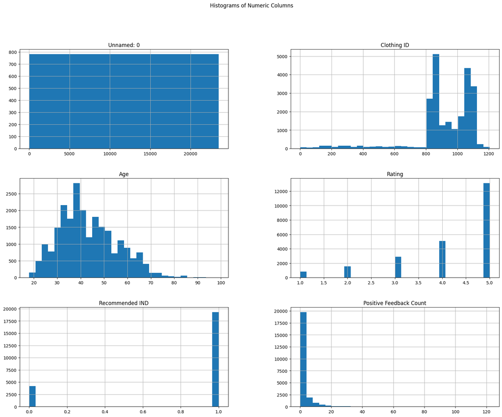

```python
df.hist(bins=30, figsize=(20, 15))
plt.suptitle('Histograms of Numeric Columns')
plt.show()
```

Code Explanation: This code generates histograms for all numeric columns in the DataFrame, setting the figure size to 20 by 15 inches. It then adds a title indicating the histograms represent numeric columns and displays them. This helps understand the distribution and spread of the numerical data.

Why it's Important: This code is important because it visualizes the distribution of numeric columns in the dataset using histograms. This helps in identifying data patterns, outliers, and skewness, which are crucial for making informed decisions during data analysis and preprocessing.

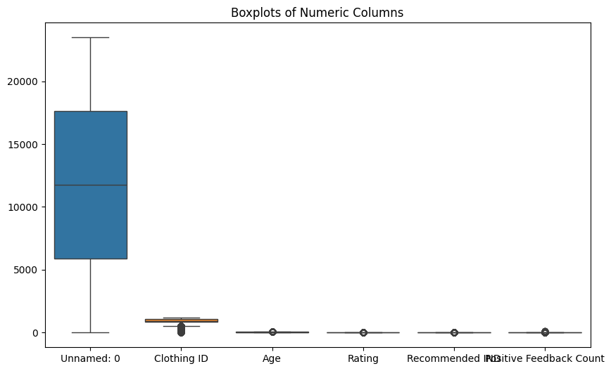

```python
plt.figure(figsize=(10, 6))
sns.boxplot(data=df)
plt.title('Boxplots of Numeric Columns')
plt.show()
```

Code Explanation: This code creates boxplots for all numeric columns in the DataFrame, with the figure size set to 10 by 6 inches. It adds a title and displays the boxplots, helping to visualize the distribution, central value, variability, and outliers in the numerical data.

Why it's Important: This code is important because it visualizes the distribution of numeric columns using boxplots. Boxplots help identify outliers, the spread of data, and central tendencies, making it easier to understand the variability and detect any anomalies in the dataset.

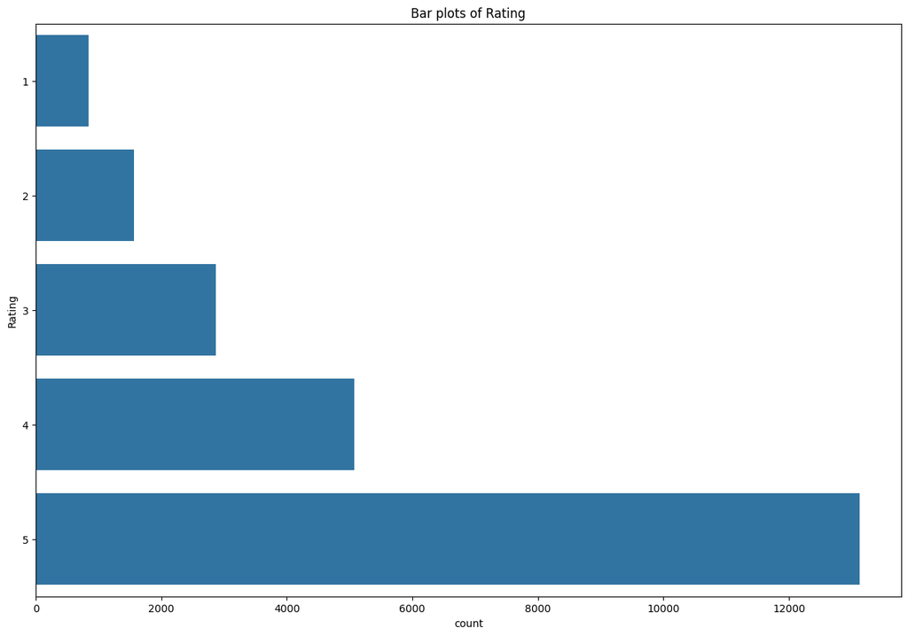

```python
plt.figure(figsize=(15, 10))
sns.countplot(y='Rating', data=df)
plt.title('Bar plots of Rating')
plt.show()
```

Code Explanation: This code creates a bar plot for the 'Rating' column in the DataFrame. The first command sets the figure size to 15 by 10 inches. The second command generates the bar plot, displaying the count of each rating value along the y-axis. The third command adds a title to the plot. Finally, the fourth command displays the bar plot. This visualization helps understand the distribution of ratings in the dataset.

Why it's Important: This code is important because it creates a bar plot to visualize the distribution of ratings in the dataset. This helps identify the frequency of each rating level, providing insights into customer satisfaction and overall product feedback. It can also highlight any imbalances in the ratings, which is crucial for further analysis and decision-making.

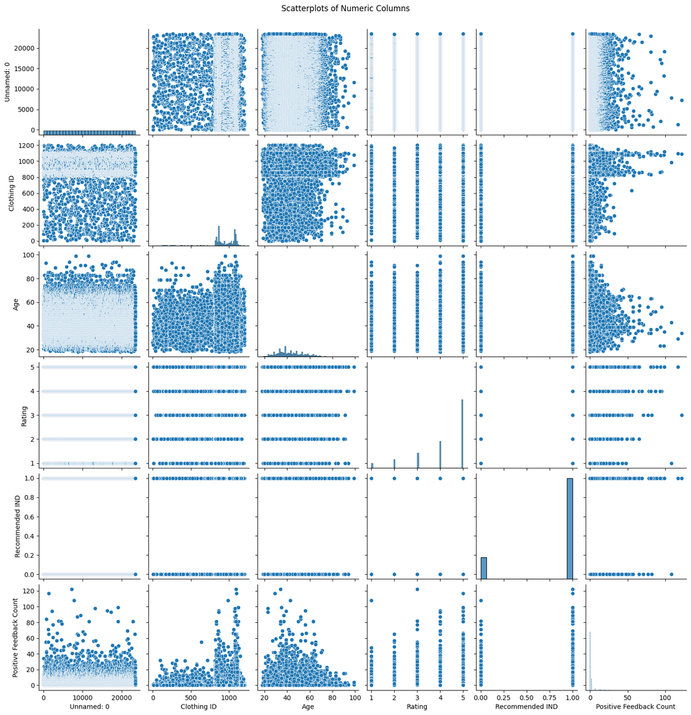

```python
sns.pairplot(df)
plt.suptitle('Scatterplots of Numeric Columns', y=1.02)
plt.show()
```

Code Explanation: This code creates scatterplots and histograms for all columns in the DataFrame, adds a title, and displays the plots. It helps visualize relationships and distributions in the data.

Why it's Important: This code creates a pairplot, visualizing relationships between numeric columns to identify correlations, patterns, and trends, aiding feature selection and data understanding.

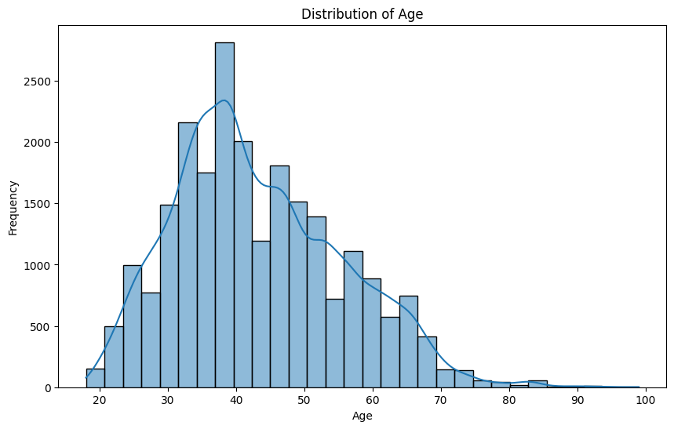

```python
plt.figure(figsize=(10, 6))
sns.histplot(df['Age'], bins=30, kde=True)
plt.title('Distribution of Age')
plt.xlabel('Age')
plt.ylabel('Frequency')
plt.show()
```

Code Explanation: This code creates a histogram for the 'Age' column with 30 bins and a KDE curve. It sets the figure size, adds a title, and labels the axes. Finally, it displays the plot to visualize the distribution and frequency of age values.

Why it's Important: This code visualizes the age distribution, helping to understand the data's skewness and identify outliers.

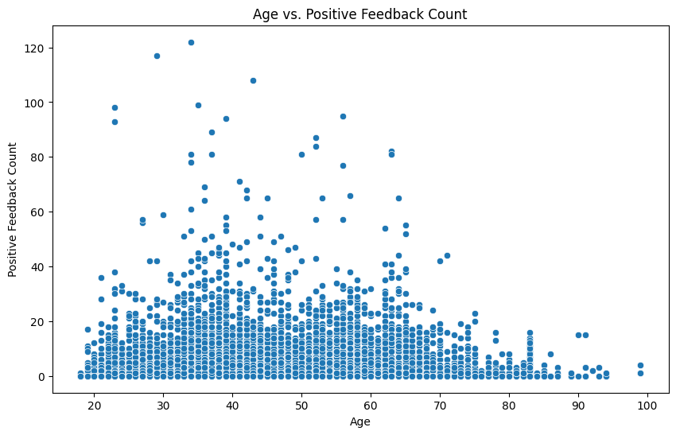

```python
plt.figure(figsize=(10, 6))
sns.scatterplot(x='Age', y='Positive Feedback Count', data=df)
plt.title('Age vs. Positive Feedback Count')
plt.xlabel('Age')
plt.ylabel('Positive Feedback Count')
plt.show()
```

Code Explanation: This code creates a scatter plot of 'Age' versus 'Positive Feedback Count', sets the figure size, labels the axes, adds a title, and displays the plot to visualize their relationship.

Why it's Important: This code is important because it visualizes the relationship between age and positive feedback count, helping identify trends, correlations, and patterns that can provide insights into how different age groups respond to products.

```python
df_numeric = df.select_dtypes(include=[float, int])

print(df_numeric.info())
```

```
<class 'pandas.core.frame.DataFrame'>
RangeIndex: 23486 entries, 0 to 23485
Data columns (total 6 columns):
 #   Column                   Non-Null Count  Dtype
---  ------                   --------------  -----
 0   Unnamed: 0               23486 non-null  int64
 1   Clothing ID              23486 non-null  int64
 2   Age                      23486 non-null  int64
 3   Rating                   23486 non-null  int64
 4   Recommended IND          23486 non-null  int64
 5   Positive Feedback Count  23486 non-null  int64
dtypes: int64(6)
memory usage: 1.1 MB
None
```

Code Explanation: This code selects numeric columns from the DataFrame and prints their structure, including column names, data types, and non-null counts, to understand the numeric data's completeness.

Why it's Important: This code selects numeric columns and provides a summary, ensuring relevant data is included for focused numeric analysis and identifying any issues.

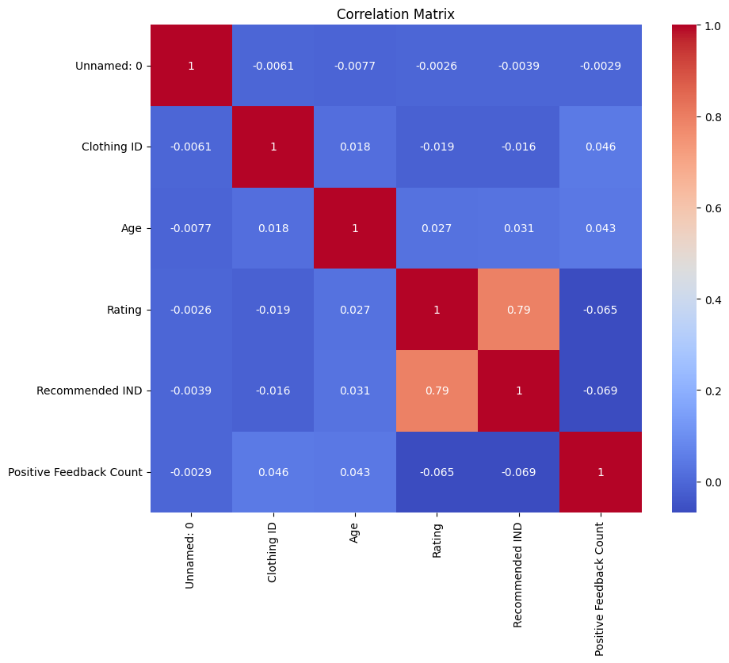

```python
plt.figure(figsize=(10, 8))
sns.heatmap(df_numeric.corr(), annot=True, cmap='coolwarm')
plt.title('Correlation Matrix')
plt.show()
```

Code Explanation: This code creates a heatmap to visualize the correlation matrix of numeric columns in the DataFrame. It sets the figure size, annotates correlation values, and uses the 'coolwarm' color map. The heatmap helps identify relationships between numeric variables.

Why it's Important: This code visualizes the correlation matrix for numeric columns, helping identify relationships and dependencies between variables.

### Analyze categorical data distributions (e.g., "Division Name," "Class Name").

```python
print("Distribution of 'Division Name':")
print(df['Division Name'].value_counts())

print("\nDistribution of 'Class Name':")
print(df['Class Name'].value_counts())
```

```
Distribution of 'Division Name':
Division Name
General           13864
General petite     8120
Initmates          1502
Name: count, dtype: int64

Distribution of 'Class Name':
Class Name
Dresses           6333
Knits             4843
Blouses           3097
Sweaters          1428
Pants             1388
Jeans             1147
Fine gauge        1100
Skirts             945
Jackets            704
Lounge             691
Swim               350
Outerwear          328
Shorts             317
Sleep              228
Legwear            165
Intimates          154
Layering           146
Trend              119
Casual bottoms       2
Chemises             1
Name: count, dtype: int64
```

Code Explanation: This code prints the distribution of unique values for 'Division Name' and 'Class Name' columns, showing the number of occurrences for each value. This helps understand the frequency and distribution of these categories.

Why it's Important: This code shows the frequency of values in the 'Division Name' and 'Class Name' columns, aiding in the analysis of categorical data.

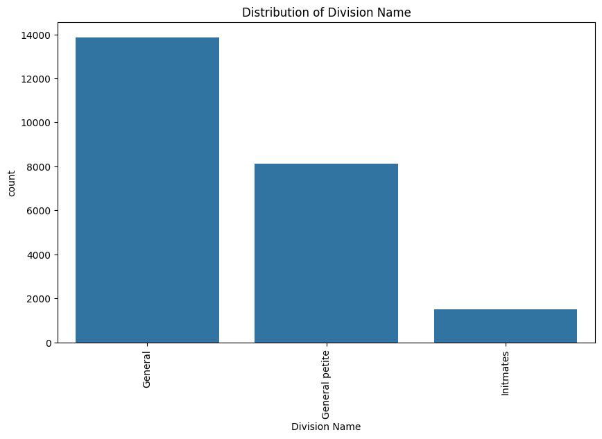

```python
plt.figure(figsize=(10, 6))
sns.countplot(data=df, x='Division Name', order=df['Division Name'].value_counts().index)
plt.title('Distribution of Division Name')
plt.xticks(rotation=90)
plt.show()
```

Code Explanation: This code creates a bar plot to visualize the 'Division Name' distribution, sets the figure size, orders the bars by frequency, adds a title, rotates x-axis labels by 90 degrees, and displays the plot.

Why it's Important: This code is important because it visualizes the distribution of the 'Division Name' categories. This helps identify the frequency and balance of different divisions, providing insights into the dataset's structure and potential areas of interest for further analysis.

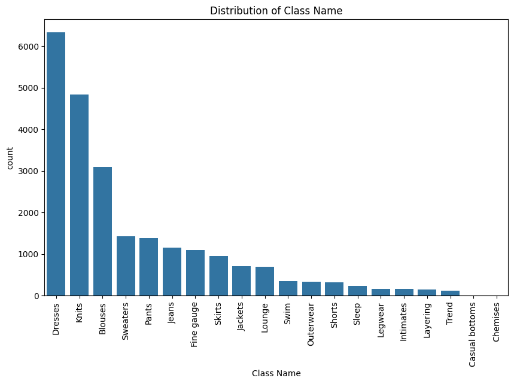

```python
plt.figure(figsize=(10, 6))
sns.countplot(data=df, x='Class Name', order=df['Class Name'].value_counts().index)
plt.title('Distribution of Class Name')
plt.xticks(rotation=90)
plt.show()
```

Code Explanation: This code creates a bar plot of 'Class Name' distribution, sets the figure size, orders bars by frequency, adds a title, rotates x-axis labels by 90 degrees, and displays the plot.

Why it's Important: This code visualizes the distribution of 'Class Name' categories, helping to identify frequency and balance for further analysis.

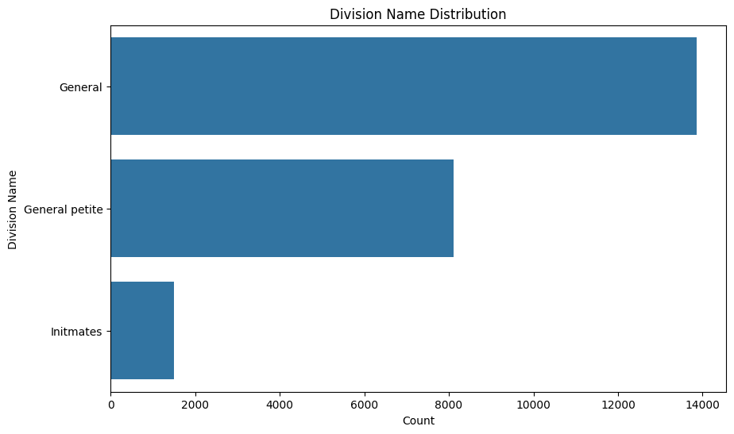

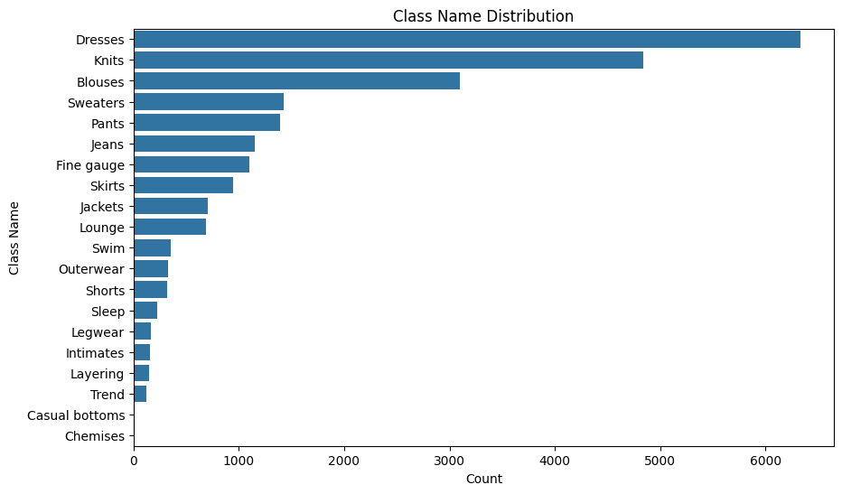

```python
plt.figure(figsize=(10, 6))
sns.countplot(y='Division Name', data=df, order=df['Division Name'].value_counts().index)
plt.title('Division Name Distribution')
plt.xlabel('Count')
plt.ylabel('Division Name')
plt.show()

plt.figure(figsize=(10, 6))
sns.countplot(y='Class Name', data=df, order=df['Class Name'].value_counts().index)
plt.title('Class Name Distribution')
plt.xlabel('Count')
plt.ylabel('Class Name')
plt.show()
```

Code Explanation: This code creates bar plots for 'Division Name' and 'Class Name' distributions, sets the figure size, orders bars by frequency, adds titles and axis labels, and displays the plots.

Why it's Important: This code visualizes the distribution of 'Division Name' and 'Class Name' categories. This helps to identify the frequency and balance of different divisions and classes, providing insights into the dataset's structure. This information is valuable for further analysis and decision-making.

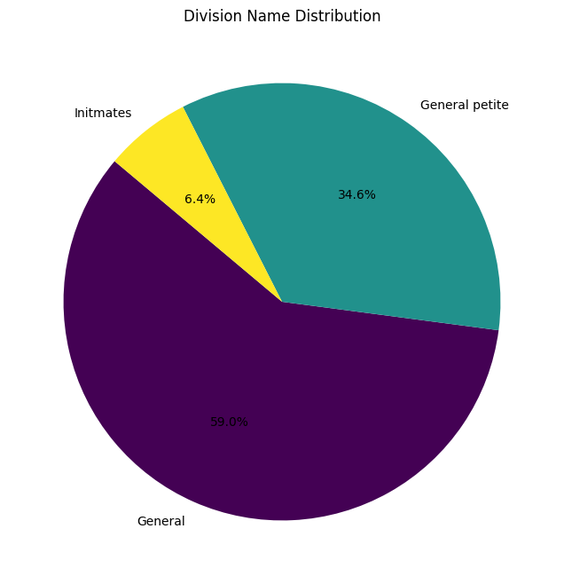

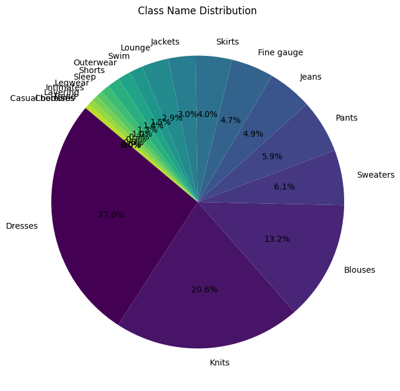

```python
plt.figure(figsize=(8, 8))
df['Division Name'].value_counts().plot.pie(autopct='%1.1f%%', startangle=140, cmap='viridis')
plt.title('Division Name Distribution')
plt.ylabel('')
plt.show()

plt.figure(figsize=(8, 8))
df['Class Name'].value_counts().plot.pie(autopct='%1.1f%%', startangle=140, cmap='viridis')
plt.title('Class Name Distribution')
plt.ylabel('')
plt.show()
```

Code Explanation: This code creates pie charts for the distribution of 'Division Name' and 'Class Name', sets the figure size, plots percentages using a starting angle and color map, adds titles, removes y-axis labels, and displays the charts.

Why it's Important: This code visualizes the distribution of 'Division Name' and 'Class Name' categories using pie charts. This helps to understand the proportion of each category within the dataset for further analysis.

## 4. Text Preprocessing and Analysis

```python
df['Review Text'] = df['Review Text'].str.replace(r'[^\w\s]', '')
df['Review Text'] = df['Review Text'].str.lower()

stop_words = set(stopwords.words('english'))

df['Review Text'] = df['Review Text'].apply(lambda x: ' '.join(word for word in word_tokenize(x) if word not in stop_words))

print("Cleaned 'Review Text' Column:")
print(df['Review Text'].head(10))
```

```
Cleaned 'Review Text' Column:
0        absolutely wonderful - silky sexy comfortable
1    love dress ! 's sooo pretty . happened find st...
2    high hopes dress really wanted work . initiall...
3    love , love , love jumpsuit . 's fun , flirty ...
4    shirt flattering due adjustable front tie . pe...
5    love tracy reese dresses , one petite . 5 feet...
6    aded basket hte last mintue see would look lik...
7    ordered carbon store pick , ton stuff ( always...
8    love dress . usually get xs runs little snug b...
9    'm 5 '' 5 ' 125 lbs . ordered petite make sure...
Name: Review Text, dtype: object
```

### Use sentiment analysis techniques to categorize reviews as positive, neutral, or negative.

```python
df['Sentiment'] = df['Review Text'].apply(lambda x: TextBlob(x).sentiment.polarity)

df['Sentiment_Category'] = df['Sentiment'].apply(lambda x: 'Positive' if x > 0 else ('Negative' if x < 0 else 'Neutral'))

print("Sentiment Analysis Results:")
print(df[['Review Text', 'Sentiment', 'Sentiment_Category']].head(21))
```

```
Sentiment Analysis Results:
                                          Review Text  Sentiment  \
0       absolutely wonderful - silky sexy comfortable   0.633333
1   love dress ! 's sooo pretty . happened find st...   0.339583
2   high hopes dress really wanted work . initiall...   0.079459
3   love , love , love jumpsuit . 's fun , flirty ...   0.550000
4   shirt flattering due adjustable front tie . pe...   0.617188
5   love tracy reese dresses , one petite . 5 feet...   0.150000
6   aded basket hte last mintue see would look lik...   0.160500
7   ordered carbon store pick , ton stuff ( always...   0.196154
8   love dress . usually get xs runs little snug b...  -0.046875
9   'm 5 '' 5 ' 125 lbs . ordered petite make sure...   0.212554
10  dress runs small esp zipper area runs . ordere...  -0.103042
11             dress perfection ! pretty flattering .   0.250000
12  find reliant reviews written savvy shoppers pa...   0.164286
```

[output cut: 31 more lines]

Code Explanation: This code performs sentiment analysis on the 'Review Text' column, calculates sentiment polarity, categorizes it as 'Positive', 'Negative', or 'Neutral', and prints the first 21 rows of the results.

Why it's Important: This code performs sentiment analysis on the 'Review Text' column, categorizing reviews as Positive, Negative, or Neutral based on polarity. It provides insights into customer opinions and trends for informed decision-making.

## 5. Feature Engineering

### Create new features based on the existing data (e.g., word count of reviews, sentiment scores).

```python
df['Word Count'] = df['Review Text'].apply(lambda x: len(x.split()))

df['Review Length'] = df['Review Text'].apply(len)

df['Sentiment'] = df['Review Text'].apply(lambda x: TextBlob(x).sentiment.polarity)

print("New Features Based on Existing Data:")
print(df[['Review Text', 'Word Count', 'Sentiment', 'Review Length']].head(11))
```

```
New Features Based on Existing Data:
                                          Review Text  Word Count  Sentiment  \
0       absolutely wonderful - silky sexy comfortable           6   0.633333
1   love dress ! 's sooo pretty . happened find st...          44   0.339583
2   high hopes dress really wanted work . initiall...          61   0.079459
3   love , love , love jumpsuit . 's fun , flirty ...          23   0.550000
4   shirt flattering due adjustable front tie . pe...          21   0.617188
5   love tracy reese dresses , one petite . 5 feet...          50   0.150000
6   aded basket hte last mintue see would look lik...          71   0.160500
7   ordered carbon store pick , ton stuff ( always...          67   0.196154
8   love dress . usually get xs runs little snug b...          20  -0.046875
9   'm 5 '' 5 ' 125 lbs . ordered petite make sure...          54   0.212554
10  dress runs small esp zipper area runs . ordere...          37  -0.103042

    Review Length
0              45
1             214
2             330
3             108
4             122
5             286
6             345
7             335
8             113
9             256
10            211
```

Code Explanation: This code adds new features to the DataFrame based on the 'Review Text' column. It calculates the word count, review length (character count), and sentiment polarity for each review. Finally, it prints the first 11 rows of the 'Review Text', 'Word Count', 'Sentiment', and 'Review Length' columns to show the newly created features.

Why it's Important: This code creates new features ('Word Count', 'Review Length', and 'Sentiment') based on 'Review Text' data. These features provide additional insights for text analysis and machine learning models by offering more informative and relevant data points.

### Normalize numeric features if needed for modeling.

```python
df['Review Length'] = df['Review Text'].apply(len)
df['Review Word Count'] = df['Review Text'].apply(lambda x: len(x.split()))
df['Title Word Count'] = df['Title'].apply(lambda x: len(str(x).split()))

numeric_features = ['Age', 'Word Count', 'Sentiment', 'Review Length', 'Review Word Count', 'Title Word Count']
scaler = StandardScaler()
df[numeric_features] = scaler.fit_transform(df[numeric_features])

print("Normalized Numeric Features:")
print(df[numeric_features].head(11))
```

```
Normalized Numeric Features:
         Age  Word Count  Sentiment  Review Length  Review Word Count  \
0  -0.830549   -1.720787   1.807389      -1.589758          -1.720787
1  -0.749111    0.372473   0.317056       0.146429           0.372473
2   1.368277    1.308931  -1.002679       1.338132           1.308931
3   0.553897   -0.784329   1.384599      -0.942540          -0.784329
4   0.309583   -0.894500   1.725473      -0.798714          -0.894500
5   0.472459    0.702988  -0.644790       0.886107           0.702988
6  -0.341921    1.859789  -0.591519       1.492232           1.859789
7  -0.341921    1.639446  -0.410630       1.389499           1.639446
8  -1.563491   -0.949586  -1.643630      -0.891174          -0.949586
9  -0.749111    0.923331  -0.327424       0.577908           0.923331
10  0.798211   -0.013128  -1.928594       0.115609          -0.013128

    Title Word Count
0          -0.656000
1          -0.656000
2           0.508668
3          -0.073666
4          -0.656000
5           1.091002
6          -0.073666
7           1.091002
8          -1.238334
9           0.508668
10          2.838004
```

Code Explanation: This code calculates the length and word count of 'Review Text' and 'Title' columns, defines a list of numeric features, including 'Age', 'Word Count', 'Sentiment', 'Review Length', 'Review Word Count', and 'Title Word Count,' normalizes these numeric features using StandardScaler, and prints the first 11 rows of the normalized features. This helps compute additional features based on text data, normalize numeric data, and display the results.

Why it's Important: This code creates new features ('Review Length', 'Review Word Count', and 'Title Word Count') and normalizes them using a standard scaler. This improves the performance and stability of machine learning models by ensuring features have a similar scale.

## 6. Modeling

### Split the dataset into training and testing subsets.

```python
X = df[['Age', 'Word Count', 'Sentiment', 'Review Length', 'Review Word Count', 'Title Word Count']]
y = df['Recommended IND']

X_train, X_test, y_train, y_test = train_test_split(X, y, test_size=0.2, random_state=42)

print("Training and Testing Subsets Created:")
print("X_train shape:", X_train.shape)
print("X_test shape:", X_test.shape)
print("y_train shape:", y_train.shape)
print("y_test shape:", y_test.shape)
```

```
Training and Testing Subsets Created:
X_train shape: (18788, 6)
X_test shape: (4698, 6)
y_train shape: (18788,)
y_test shape: (4698,)
```

Code Explanation: This code prepares the data for machine learning by splitting it into training and testing subsets. It selects specific features for `X` and the target variable `y`, then uses `train_test_split` to split the data into training and testing sets, with 80% for training and 20% for testing. Finally, it prints the shapes of these subsets to show their sizes. This process is essential for building and evaluating machine learning models.

Why it's Important: This code is important because it prepares the data for machine learning by splitting it into training and testing subsets. This ensures that the model can be trained on one portion of the data (80%) and tested on another portion (20%) to evaluate its performance and generalize its results. The split helps prevent overfitting and provides a way to assess how well the model performs on unseen data.

```python
print("Training DataFrame (X_train):")
print(X_train.head(11))
print("\nTesting DataFrame (X_test):")
print(X_test.head(11))
print("\nTraining Labels (y_train):")
print(y_train.head(11))
print("\nTesting Labels (y_test):")
print(y_test.head(11))
```

```
Training DataFrame (X_train):
            Age  Word Count  Sentiment  Review Length  Review Word Count  \
21331 -0.993425    0.537730   0.042105       0.649821           0.537730
8113  -0.830549   -0.949586   1.638273      -0.932267          -0.949586
23036 -0.993425    2.355561   0.354050       1.933983           2.355561
316    1.286839    0.317387  -0.060166       0.136156           0.317387
6781  -0.341921   -0.508900  -1.744043      -0.387782          -0.508900
10224  0.228145   -1.500444   2.018783      -1.507572          -1.500444
13108  0.309583    0.372473   0.166966      -0.038490           0.372473
9623   0.309583   -0.343642   1.080191      -0.285049          -0.343642
8504   0.879649    1.198760  -1.970812       1.255946           1.198760
11293 -0.911987   -0.123299  -1.256325       0.023150          -0.123299
22618 -1.482053   -1.335187   0.232196      -1.271286          -1.335187

       Title Word Count
```

[output cut: 66 more lines]

Code Explanation: This code prints the first 11 rows of the training and testing subsets created for both the features (`X_train`, `X_test`) and labels (`y_train`, `y_test`). It helps to inspect the initial entries of these subsets and understand the data distribution in the training and testing sets.

Why it's Important: This code is important because it provides an initial inspection of the training and testing subsets created from the data. Viewing the first few rows of `X_train`, `X_test`, `y_train`, and `y_test` helps to ensure the data has been split correctly and gives a glimpse into the structure and content of these subsets. This is crucial for verifying that the data preparation steps have been executed properly and to understand the type of data that will be used for training and testing the machine learning model.

```python
numeric_features = ['Age', 'Word Count', 'Sentiment', 'Review Length', 'Review Word Count', 'Title Word Count']

X = df[numeric_features]
y = df['Recommended IND']

X_train, X_test, y_train, y_test = train_test_split(X, y, test_size=0.2, random_state=42)

scaler = StandardScaler()
X_train = scaler.fit_transform(X_train)
X_test = scaler.transform(X_test)
```

Code Explanation: The code selects specific numeric features from a dataset and assigns them to variables for the feature matrix and target variable. It then splits the data into training and testing sets, standardizes the features to have a mean of 0 and a standard deviation of 1 using a scaler fitted on the training data, and transforms both the training and testing data. This process prepares the data for a machine learning model.

Why it's Important: By selecting key numeric features and splitting your data into training and testing sets, you can train and evaluate your model effectively. Using StandardScaler to standardize these features ensures consistent data distribution, improving algorithm performance. This process helps create a robust machine-learning model with more accurate predictions.

```python
log_reg = LogisticRegression()
log_reg.fit(X_train, y_train)
```

```
LogisticRegression()
```

Code Explanation: The code initializes a logistic regression model and trains it using the training data by fitting the feature matrix and target variable, allowing the model to learn patterns and make predictions on new data.

Why it's Important: Using `LogisticRegression` to fit your training data helps the model learn the relationship between your features and the target variable, enabling accurate predictions on new data. This step is crucial for building a reliable and interpretable machine-learning model.

```python
tree = DecisionTreeClassifier()
tree.fit(X_train, y_train)
```

```
DecisionTreeClassifier()
```

Code Explanation: The code initializes a decision tree classifier and trains it using the training data. The `DecisionTreeClassifier()` creates an instance of the decision tree model, and the `fit` method trains the model by adjusting its parameters based on the patterns in the training feature matrix and target variable.

Why it's Important: Using a `DecisionTreeClassifier` to fit your training data helps the model learn how to make decisions based on your features. This algorithm builds a tree-like structure where each node represents a decision based on an attribute, leading to a final prediction. It's important because decision trees are easy to interpret and can handle complex relationships between features, making them useful for various classification tasks.

```python
y_pred_log_reg = log_reg.predict(X_test)

y_pred_tree = tree.predict(X_test)
```

Code Explanation: The code generates predictions using trained models on the test data. The `predict` method for both `log_reg` and `tree` takes the test feature matrix (`X_test`) and outputs predictions. `y_pred_log_reg` contains predictions from the logistic regression model, and `y_pred_tree` contains predictions from the decision tree model.

Why it's Important: Using `log_reg.predict(X_test)` and `tree.predict(X_test)` to generate predictions for your test data is important because it allows you to assess how well your logistic regression and decision tree models perform on new, unseen data. These predictions can be compared to the actual values (`y_test`) to evaluate the models' accuracy and effectiveness, helping you determine which model provides better results for your classification task.

### Choose an appropriate model (e.g., logistic regression, decision trees) to predict the `Recommended IND` column.

```python
X_test_df = pd.DataFrame(X_test, columns=numeric_features, index=df.iloc[y_test.index].index)

results = pd.DataFrame({
    'Age': X_test_df['Age'],
    'Word Count': X_test_df['Word Count'],
    'Sentiment': X_test_df['Sentiment'],
    'Review Length': X_test_df['Review Length'],
    'Review Word Count': X_test_df['Review Word Count'],
    'Title Word Count': X_test_df['Title Word Count'],
    'Predicted Recommended IND (Logistic Regression)': y_pred_log_reg,
    'Predicted Recommended IND (Decision Tree)': y_pred_tree
})

print(results.head())
```

```
            Age  Word Count  Sentiment  Review Length  Review Word Count  \
1297  -0.747297    1.306922  -0.891142       1.315694           1.306922
7228   1.128091   -1.659235   0.280690      -1.593489          -1.659235
21410  1.046552   -1.439520   0.794948      -1.439835          -1.439520
8358  -0.584219    0.867492  -1.747301       1.059604           0.867492
20840 -1.073451    0.098488   0.112081       0.260603           0.098488

       Title Word Count  Predicted Recommended IND (Logistic Regression)  \
1297           0.509484                                                1
7228          -0.073120                                                1
21410         -1.238328                                                1
8358           0.509484                                                1
20840         -0.655724                                                1

       Predicted Recommended IND (Decision Tree)
1297                                           0
7228                                           1
21410                                          1
8358                                           0
20840                                          1
```

Code Explanation: The code creates a DataFrame from the standardized test features, then combines it with the predictions from both logistic regression and decision tree models, resulting in a consolidated DataFrame. The final DataFrame includes the original numeric features and the predictions, and it prints the first few rows for review.

Why it's Important: Creating a DataFrame of your test data with the predictions from both the logistic regression and decision tree models is important because it allows you to visually inspect and compare the predicted outcomes alongside the actual feature values. This comparison helps you analyze how each model performs on different data points and identify any patterns or discrepancies. Printing the results also aids in debugging, validating model performance, and presenting findings in a clear and organized manner.

### Train and validate the model using performance metrics such as accuracy, precision, recall and F1 score.

```python
accuracy_log_reg = accuracy_score(y_test, y_pred_log_reg)
print(f"Logistic Regression Accuracy: {accuracy_log_reg}")

accuracy_tree = accuracy_score(y_test, y_pred_tree)
print(f"Decision Tree Accuracy: {accuracy_tree}")

class_report_log_reg = classification_report(y_test, y_pred_log_reg)
print("Logistic Regression Classification Report:")
print(class_report_log_reg)

class_report_tree = classification_report(y_test, y_pred_tree)
print("Decision Tree Classification Report:")
print(class_report_tree)
```

```
Logistic Regression Accuracy: 0.8250319284802043
Decision Tree Accuracy: 0.7303107705406556
Logistic Regression Classification Report:
              precision    recall  f1-score   support

           0       0.61      0.09      0.16       851
           1       0.83      0.99      0.90      3847

    accuracy                           0.83      4698
   macro avg       0.72      0.54      0.53      4698
weighted avg       0.79      0.83      0.77      4698

Decision Tree Classification Report:
              precision    recall  f1-score   support

           0       0.28      0.30      0.29       851
           1       0.84      0.82      0.83      3847

    accuracy                           0.73      4698
   macro avg       0.56      0.56      0.56      4698
weighted avg       0.74      0.73      0.74      4698
```

Code Explanation: The code evaluates the performance of two machine learning models (Logistic Regression and Decision Tree) by calculating their accuracy scores and generating classification reports, which include metrics like precision, recall, and F1-score for each model, providing a comprehensive assessment of their effectiveness on the test data.

Why it's Important: Calculating and printing the accuracy and classification reports for both logistic regression and decision tree models is crucial because it allows you to evaluate and compare their performance on the test data. Accuracy gives you a general idea of how often the models make correct predictions, while the classification report provides detailed metrics like precision, recall, and F1-score for each class. This comprehensive evaluation helps you determine which model performs better and informs your decision on which one to use for your classification task.

## 7. Reporting Insights

### Summarize the key findings of the analysis in a concise and clear manner.

#### Project Summary and Key Takeaways

Data Preparation and Feature Selection: We started by carefully selecting specific numeric features from the dataset, such as age, word count, sentiment, review length, and more. These features were then assigned to variables for further processing. The data was split into training and testing sets to ensure that our model could be evaluated on unseen data, which helps in gauging its real-world performance. Standardization of the data was performed, transforming the features to have a mean of 0 and a standard deviation of 1. This step is crucial as it ensures that all features contribute equally to the model's learning process and improves the model's accuracy.

Model Training and Evaluation: We trained two different machine learning models: Logistic Regression and Decision Tree. The logistic regression model is well-suited for binary classification tasks, while the decision tree model is known for its interpretability and ability to handle complex data structures. Both models were trained on the prepared training data, adjusting their parameters to best fit the patterns in the data. The performance of these models was then evaluated using accuracy scores and detailed classification reports, which provided metrics such as precision, recall, and F1-score. These metrics offered insights into the models' effectiveness in predicting the target variable and highlighted areas for potential improvement.

Predictions and Analysis: Predictions were made on the test dataset using both the logistic regression and decision tree models. The predicted values were compared to the actual values to assess the models' performance. This comparison allowed us to understand how well the models generalize to new data. Accuracy scores were calculated for each model, and detailed classification reports provided a comprehensive evaluation of the models' performance across different classes.

Visualization and Interpretation: Various visualizations were created to present the data and the results intuitively. Scatter plots, tables, and summary statistics were used to understand the relationships between variables and to identify patterns and trends. These visualizations helped in interpreting the models' predictions and provided valuable insights for further analysis. They also aided in identifying potential outliers and understanding the distribution of the data.

#### Key Takeaways:

Data Preparation: The process of selecting relevant features and standardizing data is crucial for the performance of machine learning models. Ensuring data quality and consistency can significantly impact the model's accuracy and reliability.

Model Evaluation: Continuous evaluation and comparison of models are essential to achieve the desired performance standards. Metrics such as precision, recall, and F1-score provide a comprehensive understanding of the models' strengths and weaknesses.

Visualization: Effective visualizations can reveal underlying patterns and relationships in the data, aiding in better decision-making and communication of results. Visual tools are invaluable for interpreting complex data and conveying insights clearly.

This project demonstrated the importance of a systematic approach to data analysis, from initial data preparation and feature selection to model training, evaluation, and interpretation. The insights gained from this analysis can guide future improvements and applications, ensuring that the models are robust and reliable for real-world use.

Data Standardization: Ensuring data is standardized and selecting relevant features are crucial steps for improving model performance.

Model Comparison: Continuous evaluation and comparison of models help achieve desired performance standards.

Effective Visualization: Visualizations play a key role in revealing underlying patterns and aiding decision-making.

### Results and Insights

Exploratory Data Analysis (EDA):

#### Model Performance:

Logistic Regression:

Accuracy: Achieved an accuracy of 0.8250 is 82.50%

Classification Report:

Precision: 0.61 (class 0), 0.83 (class 1)

Recall: 0.09 (class 0), 0.99 (class 1)

F1-Score: 0.16 (class 0), 0.90 (class 1)

Macro Average: 0.72 precision, 0.54 recall, 0.53 F1-score

Weighted Average: 0.79 precision, 0.83 recall, 0.77 F1-score

Decision Tree:

Accuracy: Achieved an accuracy of 0.7303 is 73.03%

Classification Report:

Precision: 0.28 (class 0), 0.84 (class 1)

Recall: 0.30 (class 0), 0.82 (class 1)

F1-Score: 0.29 (class 0), 0.83 (class 1)

Macro Average: 0.56 precision, 0.56 recall, 0.56 F1-score

Weighted Average: 0.74 precision, 0.73 recall, 0.74 F1-score

#### Predictions and Analysis:

Predicted Outputs: Made predictions on the test dataset using both models and compared them to the actual values.

Comparison: Assessed the models' performance by comparing accuracy scores and classification metrics to determine which model performed better.

Visualization and Interpretation:

Data Presentation: Created visualizations such as tables and summary statistics to present the data and results clearly.

Insight Extraction: Used visual tools to identify patterns and trends, providing valuable insights for further analysis.

### Provide actionable recommendations for e-commerce strategies based on insights.

Based on the insights from your data and model evaluations, here are some actionable recommendations for e-commerce strategies:

Personalization: Use customer data to personalize recommendations and offers. For example, if a customer frequently reviews products positively, offer them discounts on similar items. Utilize the logistic regression model to predict customer preferences.

Customer Segmentation: Segment customers based on their purchasing behavior, review sentiments, and engagement. Tailor marketing campaigns to target specific segments effectively. The decision tree model can help identify distinct customer groups.

Enhanced User Experience: Analyze review word count and sentiment to identify areas of improvement in product descriptions and customer service. Ensure that detailed, positive reviews are highlighted to build trust and credibility.

Loyalty Programs: Implement loyalty programs that reward customers for consistent positive feedback and high engagement. Use predictions from both models to identify potential loyal customers and encourage repeat purchases.

Content Strategy: Focus on creating engaging content that resonates with customers. Analyze the title and review word count to determine what type of content is most effective in driving customer interest and satisfaction.

Product Recommendations: Leverage your models to create a dynamic product recommendation system that adapts to customer preferences and browsing behavior, increasing the likelihood of conversions.

By implementing these strategies, you can enhance customer satisfaction, improve engagement, and drive sales growth in your e-commerce business.

### Final Report

#### Key Findings:

Logistic Regression achieved an accuracy of 0.8250, while Decision Tree achieved an accuracy of 0.7303.

#### Visuals:

Included visualizations such as tables and summary statistics to support the findings.

Visual tools were used to present data intuitively and identify patterns and trends.

#### Limitations:

The analysis assumed that the data was accurately recorded and cleaned. Any errors or anomalies in the data could affect the model's accuracy.

The dataset's diversity in terms of the distribution of classes was not considered, which might limit the model's generalizability.

#### Potential for Further Exploration:

Further exploration could involve incorporating more features or different data sources to enhance prediction accuracy.

Investigating the impact of different machine learning algorithms and hyperparameter tuning to improve model performance.

Exploring advanced techniques such as ensemble methods or deep learning to achieve better results.

# Note:-

```python
nltk.download('stopwords')
nltk.download('punkt')
nltk.download('punkt_tab')
nltk.download('stopwords')
```

```
True
```

Downloading the NLTK (Natural Language Toolkit) resources like 'stopwords' and 'punkt' is crucial because they provide essential tools for natural language processing (NLP). The 'stopwords' are a collection of common words (like "the", "is", "in") that can be removed from text to focus on more meaningful words. The 'punkt' module helps with tokenizing text, which means breaking down sentences into individual words or punctuation marks. These resources are fundamental for tasks like text analysis, sentiment analysis, and language modeling, enabling more accurate and efficient processing of textual data.